# Reviewer's comment v1

Hello Kylee!

I'm happy to review your project today 🙌

My name is **Gerardo Flores** and you can find me on the HUB as https://hub.tripleten.com/u/dea170e1

You can find my comments under the heading **«Review»**. I will categorize my comments in green, blue or red boxes like this:

**Success:** if everything is done successfully

**Remarks:** if I can give some recommendations or ways to improve the project

**Needs fixing:** if the block requires some corrections. Work can't be accepted with the red comments

Please don't remove my comments. If you have any questions, don't hesitate to respond to my comments in a different section.

**Student comments:**

**Reviewer's comment v1**

**Overall Feedback**

You've done an excellent job on your project. Here’s a more detailed look:

You’ll find specific feedback in the notebook in the **Reviewer's comment v1** sections.

**🚧 Suggested Tweaks & Areas for Attention**

- From section 4 onwards, you must continue using the data corresponding to the period of time you chose, the same applies to section 5 to test your hypotheses, and it is likely that your final conclusions will be modified.

Overall, this is a very strong project submission. With the suggested refinement in the decade filtering, your notebook will be even more solid.

Great job, and keep up the excellent work!

**Reviewer's comment v2**

**Overall Feedback**

You've done an excellent job on your project. Here’s a more detailed look:

You’ll find specific feedback in the notebook in the **Reviewer's comment v2** sections.

**🚧 Suggested Tweaks & Areas for Attention**

- From section 5 you must continue using the data corresponding to the period of time you chose, it is likely that your final conclusions will be modified.

Overall, this is a very strong project submission. With the suggested refinement in the decade filtering, your notebook will be even more solid.

Great job, and keep up the excellent work!

**Reviewer's comment v3:**

Amazing job with this submission! I'm approving this project!

Your code was clean and your conclusions were well organized!

Keep up the good work! Best of luck in the next sprints!

# Video Game Sales Analysis Project

## Project Overview

In this project, you'll analyze video game sales data to identify patterns that determine a game's success. Working as an analyst for the online store Ice, you'll use this information to help plan future advertising campaigns.

## Environment Setup and Required Libraries

**Reviewer's comment v1:**

It is always helpful for the reader to have additional information about project tasks. It gives an overview of what you are going to achieve in this project.

```python
import pandas as pd
import numpy as np
import matplotlib.pyplot as plt
import seaborn as sns
from scipy import stats as st
import math# Import all required libraries
```

## Step 1: Loading and Initial Data Exploration

First, let's load our dataset and examine its basic properties:

```python
games = pd.read_csv('/datasets/games.csv')# Load the dataset
```

```python
games.sample(10)# Display basic information about the dataset
```

|  | Name | Platform | Year_of_Release | Genre | NA_sales | EU_sales | JP_sales | Other_sales | Critic_Score | User_Score | Rating |
| --- | --- | --- | --- | --- | --- | --- | --- | --- | --- | --- | --- |
| 10969 | Shrek SuperSlam | XB | 2005.0 | Action | 0.07 | 0.02 | 0.00 | 0.00 | 71.0 | 9.3 | E10+ |
| 4059 | Dragon Ball Z: Burst Limit | X360 | 2008.0 | Fighting | 0.24 | 0.18 | 0.03 | 0.05 | 72.0 | 7.6 | T |
| 16423 | Cities: Skylines Snowfall | PC | 2016.0 | Simulation | 0.00 | 0.01 | 0.00 | 0.00 | 72.0 | 7.1 | NaN |
| 13542 | Dark Arena | GBA | 2002.0 | Shooter | 0.03 | 0.01 | 0.00 | 0.00 | 65.0 | tbd | T |
| 11544 | Sentimental Graffiti: First Window | SAT | 1997.0 | Adventure | 0.00 | 0.00 | 0.08 | 0.00 | NaN | NaN | NaN |
| 6940 | Bakugan: Battle Brawlers | PS3 | 2009.0 | Action | 0.19 | 0.03 | 0.00 | 0.02 | 63.0 | 8.2 | E |
| 14557 | Judie no Atelier: Guramnat no Renkinjutsu - To... | PSP | 2010.0 | Role-Playing | 0.00 | 0.00 | 0.03 | 0.00 | NaN | NaN | NaN |
| 3129 | Crash Bandicoot Purple: Ripto's Rampage | GBA | 2004.0 | Platform | 0.46 | 0.17 | 0.00 | 0.01 | 67.0 | 6.6 | E |
| 2208 | NHL 2003 | PS2 | 2002.0 | Sports | 0.46 | 0.36 | 0.00 | 0.12 | 79.0 | 6.8 | E |
| 9979 | DreamWorks Super Star Kartz | PS3 | 2011.0 | Racing | 0.06 | 0.03 | 0.00 | 0.02 | NaN | tbd | E |

```python
games.info()
```

```
<class 'pandas.core.frame.DataFrame'>
RangeIndex: 16715 entries, 0 to 16714
Data columns (total 11 columns):
 #   Column           Non-Null Count  Dtype
---  ------           --------------  -----
 0   Name             16713 non-null  object
 1   Platform         16715 non-null  object
 2   Year_of_Release  16446 non-null  float64
 3   Genre            16713 non-null  object
 4   NA_sales         16715 non-null  float64
 5   EU_sales         16715 non-null  float64
 6   JP_sales         16715 non-null  float64
 7   Other_sales      16715 non-null  float64
 8   Critic_Score     8137 non-null   float64
 9   User_Score       10014 non-null  object
 10  Rating           9949 non-null   object
dtypes: float64(6), object(5)
memory usage: 1.4+ MB
```

```python
print(games.duplicated().sum())
# Check for duplicate entries
```

```
0
```

### Key Questions to Answer:

**Reviewer's comment v1:**

Great data overview!

## Step 2: Data Preparation

### 2.1 Standardizing Column Names

```python
games.columns = games.columns.str.lower()
# Convert column names to lowercase
```

```python
games.head(1)# Verify the changes
```

|  | name | platform | year_of_release | genre | na_sales | eu_sales | jp_sales | other_sales | critic_score | user_score | rating |
| --- | --- | --- | --- | --- | --- | --- | --- | --- | --- | --- | --- |
| 0 | Wii Sports | Wii | 2006.0 | Sports | 41.36 | 28.96 | 3.77 | 8.45 | 76.0 | 8 | E |

### 2.2 Data Type Conversion

```python
games.dtypes# Check current data types
```

```
name                object
platform            object
year_of_release    float64
genre               object
na_sales           float64
eu_sales           float64
jp_sales           float64
other_sales        float64
critic_score       float64
user_score          object
rating              object
dtype: object
```

```python
games['year_of_release'] = games['year_of_release'].astype('Int64')# Make changes to data types if necessary
```

```python
games.dtypes
```

```
name                object
platform            object
year_of_release      Int64
genre               object
na_sales           float64
eu_sales           float64
jp_sales           float64
other_sales        float64
critic_score       float64
user_score          object
rating              object
dtype: object
```

```python
games.head(1)
```

|  | name | platform | year_of_release | genre | na_sales | eu_sales | jp_sales | other_sales | critic_score | user_score | rating |
| --- | --- | --- | --- | --- | --- | --- | --- | --- | --- | --- | --- |
| 0 | Wii Sports | Wii | 2006 | Sports | 41.36 | 28.96 | 3.77 | 8.45 | 76.0 | 8 | E |

all data is kept. leaving missing data as missing is better thank falsely filled data. data cant get skewed from made up years that were falsely filled or lost.

### 2.3 Handling Missing Values

```python
games.isnull().sum()
```

```
name                  2
platform              0
year_of_release     269
genre                 2
na_sales              0
eu_sales              0
jp_sales              0
other_sales           0
critic_score       8578
user_score         6701
rating             6766
dtype: int64
```

```python
(games.isnull().sum() / len(games)) * 100 # Calculate percentage of missing values
```

```
name                0.011965
platform            0.000000
year_of_release     1.609333
genre               0.011965
na_sales            0.000000
eu_sales            0.000000
jp_sales            0.000000
other_sales         0.000000
critic_score       51.319174
user_score         40.089740
rating             40.478612
dtype: float64
```

half of our missing data is the critic score. it is common for games not to recieve a critic score. the game must meet certain criteria to qualify for a critic score.

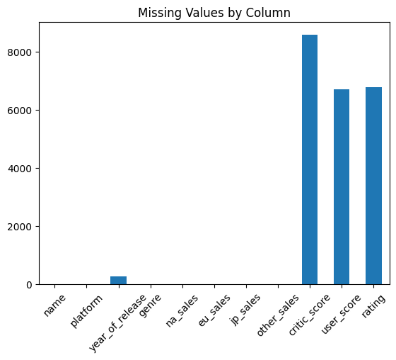

```python
games.isnull().sum().plot(kind='bar',rot=45)
plt.title("Missing Values by Column")
plt.show()# Analyze patterns in missing values
```

```python
games_clean = games.dropna(subset=['rating'])

print(f"Original dataset size: {len(games)}")
print(f"After removing missing ratings: {len(games_clean)}")
print(f"Removed {len(games) - len(games_clean)} rows with missing ratings")
# Handle missing values based on analysis
# Your code here to handle missing values according to your strategy
```

```
Original dataset size: 16715
After removing missing ratings: 9949
Removed 6766 rows with missing ratings
```

```python
print("rating")
print(games_clean['rating'])
```

```
rating
0           E
2           E
3           E
6           E
7           E
         ...
16697       E
16698       E
16702    E10+
16704       E
16706       T
Name: rating, Length: 9949, dtype: object
```

```python
games_clean = games.dropna(subset=['user_score'])

print(f"Original dataset size: {len(games)}")
print(f"After removing missing user scores: {len(games_clean)}")
print(f"Removed {len(games) - len(games_clean)} rows with missing user scores")
print()
print("User Score")
print(games_clean['user_score'])
```

```
Original dataset size: 16715
After removing missing user scores: 10014
Removed 6701 rows with missing user scores

User Score
0          8
2        8.3
3          8
6        8.5
7        6.6
        ...
16698    tbd
16702    7.2
16704    tbd
16705    5.8
16706    tbd
Name: user_score, Length: 10014, dtype: object
```

```python
games_clean = games.dropna(subset=['critic_score'])

print(f"Original dataset size: {len(games)}")
print(f"After removing missing critic scores: {len(games_clean)}")
print(f"Removed {len(games) - len(games_clean)} rows with missing critic scores")
print()
print("Critic Score")
print(games_clean['critic_score'])
```

```
Original dataset size: 16715
After removing missing critic scores: 8137
Removed 8578 rows with missing critic scores

Critic Score
0        76.0
2        82.0
3        80.0
6        89.0
7        58.0
         ...
16696    61.0
16697    53.0
16698    48.0
16702    60.0
16705    63.0
Name: critic_score, Length: 8137, dtype: float64
```

**Reviewer's comment v1:**

When we have so many missing values, a strategy we can use is to keep those missing values, since if we remove the rows that have them, we are getting rid of practically half of our data. Therefore, on this occasion, the strategy should be to keep those missing values in order not to bias our data or lose the representativeness of the population.

I mark it in green since you are storing the data in new variables

# Why do you think the values are missing? Give possible reasons.

it is common for games not to recieve a critic score. the game must meet certain criteria to qualify for a critic score.

the ESRB rating system is voluntary, meaning not all games are required to have a rating. some games may choose not to participate in the rating process.

some games may not receive user scores due to low amount of reviews along with whether the games platform allowed one.

# Explain why you filled in the missing values as you did or why you decided to leave them blank.

i dropped the ones with missing values so it would be easier to figure out the mean of given scores per platform/games later on.

### 2.4 Calculate Total Sales

```python
games['total_sales'] = games['na_sales'] + games['eu_sales'] + games['jp_sales'] + games['other_sales']

print(games.sample(10))# Calculate total sales across all regions and put them in a different column
```

```
                                           name platform  year_of_release  \
14508                    Gensou Suikoden I & II      PSP             2006
10355                                Fit in Six      Wii             2011
14357           Mystery Case Files: Ravenhearst       PC             2007
2010                       Donkey Kong Land III       GB             <NA>
15496       Lara Croft and the Temple of Osiris       PC             2014
8211                     SEGA Bass Fishing Duel      PS2             2002
1664   Naruto Shippuden: Ultimate Ninja Storm 2      PS3             2010
2316                              X-Men Legends       XB             2004
8672                               Arcana Heart      PS2             2007
14915          Divinity II: Flames of Vengeance       PC             2010

              genre  na_sales  eu_sales  jp_sales  other_sales  critic_score  \
14508  Role-Playing      0.00      0.00      0.03         0.00           NaN
10355        Sports      0.10      0.00      0.00         0.01           NaN
```

[output cut: 20 more lines]

# Step 3: Analyzing Video Game Sales Data

## 3.1 Temporal Analysis of Game Releases

Let's first examine the distribution of game releases across different years to understand our data's coverage and significance:

```python
releases_df = games.groupby('year_of_release').size().to_frame(name='game_count')
# Create a DataFrame with game releases by year
```

```python
releases_df# Visualize the distribution of games across years
```

| year_of_release | game_count |
| --- | --- |
| 1980 | 9 |
| 1981 | 46 |
| 1982 | 36 |
| 1983 | 17 |
| 1984 | 14 |
| 1985 | 14 |
| 1986 | 21 |
| 1987 | 16 |
| 1988 | 15 |
| 1989 | 17 |
| 1990 | 16 |
| 1991 | 41 |
| 1992 | 43 |
| 1993 | 62 |
| 1994 | 121 |
| 1995 | 219 |
| 1996 | 263 |
| 1997 | 289 |
| 1998 | 379 |
| 1999 | 338 |
| 2000 | 350 |
| 2001 | 482 |
| 2002 | 829 |
| 2003 | 775 |
| 2004 | 762 |
| 2005 | 939 |
| 2006 | 1006 |
| 2007 | 1197 |
| 2008 | 1427 |
| 2009 | 1426 |
| 2010 | 1255 |
| 2011 | 1136 |
| 2012 | 653 |
| 2013 | 544 |
| 2014 | 581 |
| 2015 | 606 |
| 2016 | 502 |

```python
print("Summary Statistics for Game Releases by Year:")
print(releases_df['game_count'].describe())
print(f"Total years in dataset: {len(releases_df)}")
print(f"Peak year: {releases_df['game_count'].idxmax()} with {releases_df['game_count'].max()}games")
print(f"Lowest year: {releases_df['game_count'].idxmin()} with {releases_df['game_count'].min()}games")# Display summary statistics for each year
```

```
Summary Statistics for Game Releases by Year:
count      37.000000
mean      444.486486
std       451.557159
min         9.000000
25%        36.000000
50%       338.000000
75%       762.000000
max      1427.000000
Name: game_count, dtype: float64
Total years in dataset: 37
Peak year: 2008 with 1427games
Lowest year: 1980 with 9games
```

### Questions to Consider:

- Which years show significant numbers of game releases? -- 2006 - 2011 were over 1,000 whereas every other year are below.
- Are there any notable trends or patterns in the number of releases? -- releases really started to climb come 2000, peaking in 2008/2009. releases dropped back under 1000 a couple years later.
- Is there enough recent data to make predictions for 2017? -- i would say no - going further into the analysis, i would now say yes. this early into the analysis it was really hard to gauge.

**Reviewer's comment v1:**

How much data do you think would be necessary for you to consider that there is enough data to make predictions?

## 3.2 Platform Sales Analysis Over Time

Now let's analyze how sales vary across platforms and years:

```python
platform_sales = games.groupby(['platform', 'year_of_release'])['total_sales'].sum()
# Calculate total sales by platform and year
print(platform_sales)
```

```
platform  year_of_release
2600      1980               11.38
          1981               35.68
          1982               28.88
          1983                5.84
          1984                0.27
                             ...
XB        2008                0.18
XOne      2013               18.96
          2014               54.07
          2015               60.14
          2016               26.15
Name: total_sales, Length: 238, dtype: float64
```

```python
heatmap_data = games.pivot_table(
    values='total_sales',
    index='platform',
    columns='year_of_release',
    aggfunc='sum',
    fill_value=0
)# Create a heatmap of platform sales over time
```

```python
heatmap_data
```

| year_of_release platform | 1980 | 1981 | 1982 | 1983 | 1984 | 1985 | 1986 | 1987 | 1988 | 1989 | ... | 2007 | 2008 | 2009 | 2010 | 2011 | 2012 | 2013 | 2014 | 2015 | 2016 |
| --- | --- | --- | --- | --- | --- | --- | --- | --- | --- | --- | --- | --- | --- | --- | --- | --- | --- | --- | --- | --- | --- |
| 2600 | 11.38 | 35.68 | 28.88 | 5.84 | 0.27 | 0.45 | 0.67 | 1.94 | 0.74 | 0.63 | ... | 0.00 | 0.00 | 0.00 | 0.00 | 0.00 | 0.00 | 0.00 | 0.00 | 0.00 | 0.00 |
| 3DO | 0.00 | 0.00 | 0.00 | 0.00 | 0.00 | 0.00 | 0.00 | 0.00 | 0.00 | 0.00 | ... | 0.00 | 0.00 | 0.00 | 0.00 | 0.00 | 0.00 | 0.00 | 0.00 | 0.00 | 0.00 |
| 3DS | 0.00 | 0.00 | 0.00 | 0.00 | 0.00 | 0.00 | 0.00 | 0.00 | 0.00 | 0.00 | ... | 0.00 | 0.00 | 0.00 | 0.00 | 63.20 | 51.36 | 56.57 | 43.76 | 27.78 | 15.14 |
| DC | 0.00 | 0.00 | 0.00 | 0.00 | 0.00 | 0.00 | 0.00 | 0.00 | 0.00 | 0.00 | ... | 0.02 | 0.04 | 0.00 | 0.00 | 0.00 | 0.00 | 0.00 | 0.00 | 0.00 | 0.00 |
| DS | 0.00 | 0.00 | 0.00 | 0.00 | 0.00 | 0.02 | 0.00 | 0.00 | 0.00 | 0.00 | ... | 146.94 | 145.31 | 119.54 | 85.02 | 26.18 | 11.01 | 1.54 | 0.00 | 0.00 | 0.00 |
| GB | 0.00 | 0.00 | 0.00 | 0.00 | 0.00 | 0.00 | 0.00 | 0.00 | 1.43 | 64.97 | ... | 0.00 | 0.00 | 0.00 | 0.00 | 0.00 | 0.00 | 0.00 | 0.00 | 0.00 | 0.00 |
| GBA | 0.00 | 0.00 | 0.00 | 0.00 | 0.00 | 0.00 | 0.00 | 0.00 | 0.00 | 0.00 | ... | 3.40 | 0.00 | 0.00 | 0.00 | 0.00 | 0.00 | 0.00 | 0.00 | 0.00 | 0.00 |
| GC | 0.00 | 0.00 | 0.00 | 0.00 | 0.00 | 0.00 | 0.00 | 0.00 | 0.00 | 0.00 | ... | 0.27 | 0.00 | 0.00 | 0.00 | 0.00 | 0.00 | 0.00 | 0.00 | 0.00 | 0.00 |
| GEN | 0.00 | 0.00 | 0.00 | 0.00 | 0.00 | 0.00 | 0.00 | 0.00 | 0.00 | 0.00 | ... | 0.00 | 0.00 | 0.00 | 0.00 | 0.00 | 0.00 | 0.00 | 0.00 | 0.00 | 0.00 |
| GG | 0.00 | 0.00 | 0.00 | 0.00 | 0.00 | 0.00 | 0.00 | 0.00 | 0.00 | 0.00 | ... | 0.00 | 0.00 | 0.00 | 0.00 | 0.00 | 0.00 | 0.00 | 0.00 | 0.00 | 0.00 |
| N64 | 0.00 | 0.00 | 0.00 | 0.00 | 0.00 | 0.00 | 0.00 | 0.00 | 0.00 | 0.00 | ... | 0.00 | 0.00 | 0.00 | 0.00 | 0.00 | 0.00 | 0.00 | 0.00 | 0.00 | 0.00 |
| NES | 0.00 | 0.00 | 0.00 | 10.96 | 50.08 | 53.44 | 36.41 | 19.76 | 45.01 | 7.85 | ... | 0.00 | 0.00 | 0.00 | 0.00 | 0.00 | 0.00 | 0.00 | 0.00 | 0.00 | 0.00 |
| NG | 0.00 | 0.00 | 0.00 | 0.00 | 0.00 | 0.00 | 0.00 | 0.00 | 0.00 | 0.00 | ... | 0.00 | 0.00 | 0.00 | 0.00 | 0.00 | 0.00 | 0.00 | 0.00 | 0.00 | 0.00 |
| PC | 0.00 | 0.00 | 0.00 | 0.00 | 0.00 | 0.04 | 0.00 | 0.00 | 0.03 | 0.00 | ... | 9.28 | 12.42 | 16.91 | 24.28 | 35.03 | 23.22 | 12.38 | 13.28 | 8.52 | 5.25 |
| PCFX | 0.00 | 0.00 | 0.00 | 0.00 | 0.00 | 0.00 | 0.00 | 0.00 | 0.00 | 0.00 | ... | 0.00 | 0.00 | 0.00 | 0.00 | 0.00 | 0.00 | 0.00 | 0.00 | 0.00 | 0.00 |
| PS | 0.00 | 0.00 | 0.00 | 0.00 | 0.00 | 0.00 | 0.00 | 0.00 | 0.00 | 0.00 | ... | 0.00 | 0.00 | 0.00 | 0.00 | 0.00 | 0.00 | 0.00 | 0.00 | 0.00 | 0.00 |
| PS2 | 0.00 | 0.00 | 0.00 | 0.00 | 0.00 | 0.00 | 0.00 | 0.00 | 0.00 | 0.00 | ... | 75.99 | 53.90 | 26.40 | 5.64 | 0.45 | 0.00 | 0.00 | 0.00 | 0.00 | 0.00 |
| PS3 | 0.00 | 0.00 | 0.00 | 0.00 | 0.00 | 0.00 | 0.00 | 0.00 | 0.00 | 0.00 | ... | 73.19 | 118.52 | 130.93 | 142.17 | 156.78 | 107.36 | 113.25 | 47.76 | 16.82 | 3.60 |
| PS4 | 0.00 | 0.00 | 0.00 | 0.00 | 0.00 | 0.00 | 0.00 | 0.00 | 0.00 | 0.00 | ... | 0.00 | 0.00 | 0.00 | 0.00 | 0.00 | 0.00 | 25.99 | 100.00 | 118.90 | 69.25 |
| PSP | 0.00 | 0.00 | 0.00 | 0.00 | 0.00 | 0.00 | 0.00 | 0.00 | 0.00 | 0.00 | ... | 46.93 | 34.55 | 37.78 | 35.04 | 17.82 | 7.69 | 3.14 | 0.24 | 0.12 | 0.00 |
| PSV | 0.00 | 0.00 | 0.00 | 0.00 | 0.00 | 0.00 | 0.00 | 0.00 | 0.00 | 0.00 | ... | 0.00 | 0.00 | 0.00 | 0.00 | 4.63 | 16.19 | 10.59 | 11.90 | 6.25 | 4.25 |
| SAT | 0.00 | 0.00 | 0.00 | 0.00 | 0.00 | 0.00 | 0.00 | 0.00 | 0.00 | 0.00 | ... | 0.00 | 0.00 | 0.00 | 0.00 | 0.00 | 0.00 | 0.00 | 0.00 | 0.00 | 0.00 |
| SCD | 0.00 | 0.00 | 0.00 | 0.00 | 0.00 | 0.00 | 0.00 | 0.00 | 0.00 | 0.00 | ... | 0.00 | 0.00 | 0.00 | 0.00 | 0.00 | 0.00 | 0.00 | 0.00 | 0.00 | 0.00 |
| SNES | 0.00 | 0.00 | 0.00 | 0.00 | 0.00 | 0.00 | 0.00 | 0.00 | 0.00 | 0.00 | ... | 0.00 | 0.00 | 0.00 | 0.00 | 0.00 | 0.00 | 0.00 | 0.00 | 0.00 | 0.00 |
| TG16 | 0.00 | 0.00 | 0.00 | 0.00 | 0.00 | 0.00 | 0.00 | 0.00 | 0.00 | 0.00 | ... | 0.00 | 0.00 | 0.00 | 0.00 | 0.00 | 0.00 | 0.00 | 0.00 | 0.00 | 0.00 |
| WS | 0.00 | 0.00 | 0.00 | 0.00 | 0.00 | 0.00 | 0.00 | 0.00 | 0.00 | 0.00 | ... | 0.00 | 0.00 | 0.00 | 0.00 | 0.00 | 0.00 | 0.00 | 0.00 | 0.00 | 0.00 |
| Wii | 0.00 | 0.00 | 0.00 | 0.00 | 0.00 | 0.00 | 0.00 | 0.00 | 0.00 | 0.00 | ... | 152.77 | 171.32 | 206.97 | 127.95 | 59.65 | 21.71 | 8.59 | 3.75 | 1.14 | 0.18 |
| WiiU | 0.00 | 0.00 | 0.00 | 0.00 | 0.00 | 0.00 | 0.00 | 0.00 | 0.00 | 0.00 | ... | 0.00 | 0.00 | 0.00 | 0.00 | 0.00 | 17.56 | 21.65 | 22.03 | 16.35 | 4.60 |
| X360 | 0.00 | 0.00 | 0.00 | 0.00 | 0.00 | 0.00 | 0.00 | 0.00 | 0.00 | 0.00 | ... | 95.41 | 135.26 | 120.29 | 170.03 | 143.84 | 99.74 | 88.58 | 34.74 | 11.96 | 1.52 |
| XB | 0.00 | 0.00 | 0.00 | 0.00 | 0.00 | 0.00 | 0.00 | 0.00 | 0.00 | 0.00 | ... | 0.55 | 0.18 | 0.00 | 0.00 | 0.00 | 0.00 | 0.00 | 0.00 | 0.00 | 0.00 |
| XOne | 0.00 | 0.00 | 0.00 | 0.00 | 0.00 | 0.00 | 0.00 | 0.00 | 0.00 | 0.00 | ... | 0.00 | 0.00 | 0.00 | 0.00 | 0.00 | 0.00 | 18.96 | 54.07 | 60.14 | 26.15 |

31 rows × 37 columns

```python
recent_years = heatmap_data.iloc[:, -5:]  # Last 5 years
print(recent_years)# Identify platforms with declining sales
```

```
year_of_release    2012    2013    2014    2015   2016
platform
2600               0.00    0.00    0.00    0.00   0.00
3DO                0.00    0.00    0.00    0.00   0.00
3DS               51.36   56.57   43.76   27.78  15.14
DC                 0.00    0.00    0.00    0.00   0.00
DS                11.01    1.54    0.00    0.00   0.00
GB                 0.00    0.00    0.00    0.00   0.00
GBA                0.00    0.00    0.00    0.00   0.00
GC                 0.00    0.00    0.00    0.00   0.00
GEN                0.00    0.00    0.00    0.00   0.00
GG                 0.00    0.00    0.00    0.00   0.00
N64                0.00    0.00    0.00    0.00   0.00
NES                0.00    0.00    0.00    0.00   0.00
NG                 0.00    0.00    0.00    0.00   0.00
PC                23.22   12.38   13.28    8.52   5.25
PCFX               0.00    0.00    0.00    0.00   0.00
PS                 0.00    0.00    0.00    0.00   0.00
PS2                0.00    0.00    0.00    0.00   0.00
PS3              107.36  113.25   47.76   16.82   3.60
PS4                0.00   25.99  100.00  118.90  69.25
PSP                7.69    3.14    0.24    0.12   0.00
PSV               16.19   10.59   11.90    6.25   4.25
SAT                0.00    0.00    0.00    0.00   0.00
SCD                0.00    0.00    0.00    0.00   0.00
SNES               0.00    0.00    0.00    0.00   0.00
TG16               0.00    0.00    0.00    0.00   0.00
WS                 0.00    0.00    0.00    0.00   0.00
Wii               21.71    8.59    3.75    1.14   0.18
WiiU              17.56   21.65   22.03   16.35   4.60
X360              99.74   88.58   34.74   11.96   1.52
XB                 0.00    0.00    0.00    0.00   0.00
XOne               0.00   18.96   54.07   60.14  26.15
```

```python
print("Data shape:", heatmap_data.shape)
print("Years covered:", heatmap_data.columns.min(), "to", heatmap_data.columns.max())
print("\nLast few years:")
print(heatmap_data.columns[-5])
```

```
Data shape: (31, 37)
Years covered: 1980 to 2016

Last few years:
2012
```

```python
most_recent_year = heatmap_data.columns[-1]
print(f"Most recent year: {most_recent_year}")

zero_recent_sales = heatmap_data[heatmap_data[most_recent_year] == 0]
print(f"\nPlatforms with zero sales in {most_recent_year}:")
print(zero_recent_sales.index.tolist())
```

```
Most recent year: 2016

Platforms with zero sales in 2016:
['2600', '3DO', 'DC', 'DS', 'GB', 'GBA', 'GC', 'GEN', 'GG', 'N64', 'NES', 'NG', 'PCFX', 'PS', 'PS2', 'PSP', 'SAT', 'SCD', 'SNES', 'TG16', 'WS', 'XB']
```

### Questions to Consider:

- Which platforms show consistent sales over time? -- pc, ps, xbox.
- Can you identify platforms that have disappeared from the market? nintendo owns several different consoles that each have their own era. several close to all have died. though with nintendo consoles - a trend of when one dies, another comes to life.
- What's the typical lifecycle of a gaming platform? -- the typical lifecycle of a gaming flatform is around 8-12 years.

**Reviewer's comment v1:**

Well done!

## 3.3 Determining Relevant Time Period

Based on your analysis above, determine the appropriate time period for predicting 2017 sales:

```python
years_2000_plus = [col for col in heatmap_data.columns if col >= 2000]
recent_data = heatmap_data[years_2000_plus]

print("Years included:", years_2000_plus)
print("Data shape:", recent_data.shape)
```

```
Years included: [2000, 2001, 2002, 2003, 2004, 2005, 2006, 2007, 2008, 2009, 2010, 2011, 2012, 2013, 2014, 2015, 2016]
Data shape: (31, 17)
```

```python
platform_totals = recent_data.sum(axis=1)

# Show platforms with their total sales
print("Platform total sales (2000-2016):")
print(platform_totals.sort_values(ascending=False))

# Filter to only platforms with sales > 0
platforms_with_sales = recent_data[platform_totals > 0]

print(f"\nPlatforms with sales: {len(platforms_with_sales)}")
print(f"Platforms filtered out: {len(recent_data) - len(platforms_with_sales)}")
```

```
Platform total sales (2000-2016):
platform
PS2     1233.56
X360     961.24
PS3      931.34
Wii      891.18
DS       802.76
PS4      314.14
GBA      312.88
PSP      289.53
3DS      257.81
XB       251.57
PC       205.72
GC       196.73
XOne     159.32
PS       140.70
WiiU      82.19
PSV       53.81
N64       37.30
GB        29.00
DC         7.41
WS         0.96
PCFX       0.00
TG16       0.00
GEN        0.00
SCD        0.00
SNES       0.00
3DO        0.00
SAT        0.00
GG         0.00
NES        0.00
NG         0.00
2600       0.00
dtype: float64

Platforms with sales: 20
Platforms filtered out: 11
```

```python
console_platforms = ['PS2', 'PS3', 'PS4', 'PS', 'X360', 'XB', 'XOne', 'Wii', 'WiiU', 'GC', 'N64', 'DC']
handheld_platforms = ['DS', '3DS', 'GBA', 'PSP', 'PSV', 'GB']
other_platforms = ['PC']

# Filter to just console platforms that have sales
console_data = platforms_with_sales.loc[
    [platform for platform in console_platforms if platform in platforms_with_sales.index]
]

print("Console platforms with sales:")
print(console_data.index.tolist())
print(f"Number of console platforms: {len(console_data)}")
```

```
Console platforms with sales:
['PS2', 'PS3', 'PS4', 'PS', 'X360', 'XB', 'XOne', 'Wii', 'WiiU', 'GC', 'N64', 'DC']
Number of console platforms: 12
```

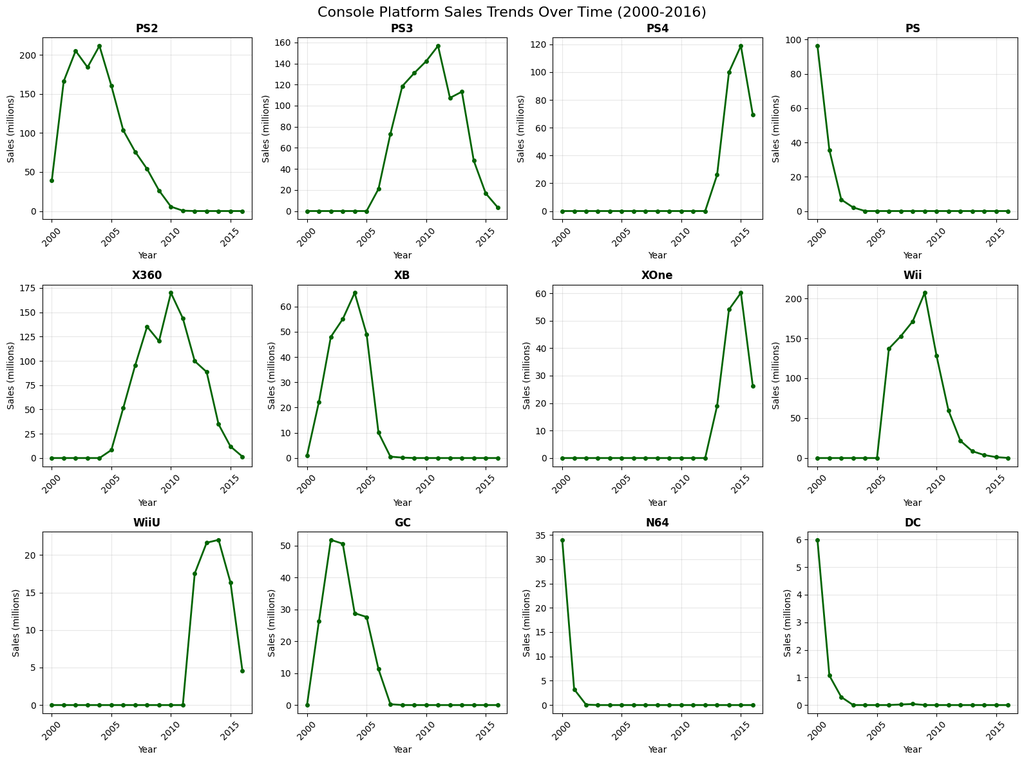

```python
fig, axes = plt.subplots(3, 4, figsize=(16, 12))
fig.suptitle('Console Platform Sales Trends Over Time (2000-2016)', fontsize=16)

# Flatten axes array for easier iteration
axes_flat = axes.flatten()

# Plot each console platform in its own subplot
for i, platform in enumerate(console_data.index):
    ax = axes_flat[i]

    # Plot the trend line for this platform
    ax.plot(console_data.columns, console_data.loc[platform],
            marker='o', linewidth=2, markersize=4, color='darkgreen')

    ax.set_title(f'{platform}', fontsize=12, fontweight='bold')
    ax.set_xlabel('Year')
    ax.set_ylabel('Sales (millions)')
    ax.grid(True, alpha=0.3)
    ax.tick_params(axis='x', rotation=45)

plt.tight_layout()
plt.show()
```

### Document Your Decision:

- What years did you select and why? -- selected 2000 to present. this gives a great range of years to include the lifecycle of a game platform, then allows us to look at trends in new updated consoles from same companies. this will help add more layers to the cake of total analysis for future prediction.
- How does this period reflect current market conditions? -- we can look at trends per company with their sales per console. PS3 died down tremendously, whereas PS4 shot up at the same time. Same with old/new Xbox and Nintendo consoles.
- What factors influenced your decision? -- looking at genre sales was too messy. consoles have lifecycles, genres dont. choosing console, you can look at stats vs competitor, and see whether users are holding off on buying games, if a new console is predicted to release - this is an important factor when considering fluctuations.

**Reviewer's comment v1:**

Well done!

## 3.4 Platform Performance Analysis

Using your selected time period, let's analyze platform performance:

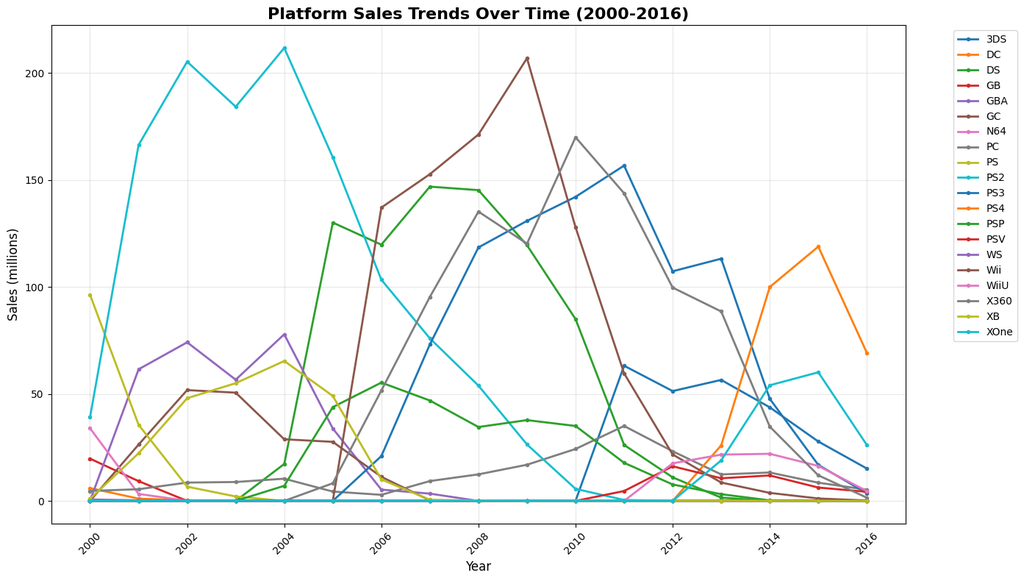

```python
plt.figure(figsize=(14, 8))

# Plot each platform as a separate line
for platform in platforms_with_sales.index:
    plt.plot(platforms_with_sales.columns, platforms_with_sales.loc[platform],
             marker='o', linewidth=2, markersize=3, label=platform)

plt.title('Platform Sales Trends Over Time (2000-2016)', fontsize=16, fontweight='bold')
plt.xlabel('Year', fontsize=12)
plt.ylabel('Sales (millions)', fontsize=12)
plt.legend(bbox_to_anchor=(1.05, 1), loc='upper left')
plt.grid(True, alpha=0.3)
plt.xticks(rotation=45)
plt.tight_layout()
plt.show()# Analyze platform sales trends
```

```python
platform_totals = platforms_with_sales.sum(axis=1)

platform_totals_sorted = platform_totals.sort_values(ascending=False)

print("\nPlatforms sorted by total sales (highest to lowest):")
print(platform_totals_sorted)# Sort platforms by total sales
```

```
Platforms sorted by total sales (highest to lowest):
platform
PS2     1233.56
X360     961.24
PS3      931.34
Wii      891.18
DS       802.76
PS4      314.14
GBA      312.88
PSP      289.53
3DS      257.81
XB       251.57
PC       205.72
GC       196.73
XOne     159.32
PS       140.70
WiiU      82.19
PSV       53.81
N64       37.30
GB        29.00
DC         7.41
WS         0.96
dtype: float64
```

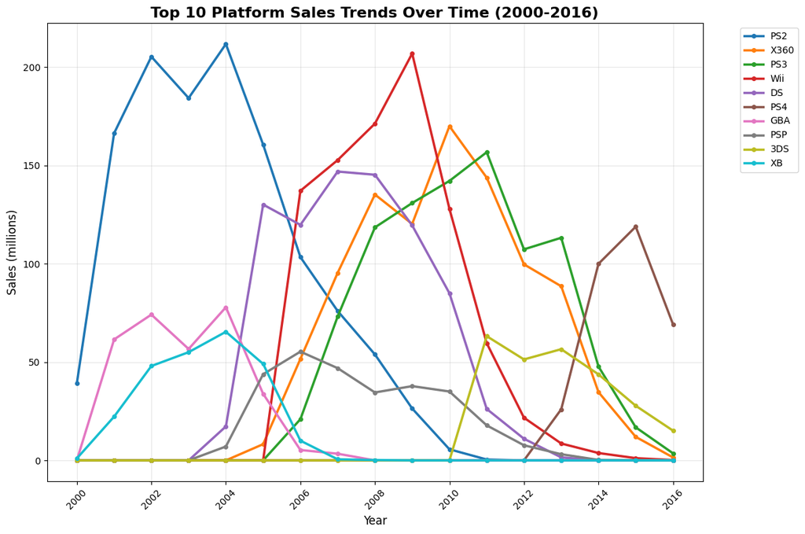

```
Top 10 platforms by total sales:
platform
PS2     1233.56
X360     961.24
PS3      931.34
Wii      891.18
DS       802.76
PS4      314.14
GBA      312.88
PSP      289.53
3DS      257.81
XB       251.57
dtype: float64
```

```python
top_platforms = platforms_with_sales.sum(axis=1).sort_values(ascending=False).head(10)
top_platform_data = platforms_with_sales.loc[top_platforms.index]

plt.figure(figsize=(12, 8))

# Plot each top platform
for platform in top_platform_data.index:
    plt.plot(top_platform_data.columns, top_platform_data.loc[platform],
             marker='o', linewidth=2.5, markersize=4, label=platform)

plt.title('Top 10 Platform Sales Trends Over Time (2000-2016)', fontsize=16, fontweight='bold')
plt.xlabel('Year', fontsize=12)
plt.ylabel('Sales (millions)', fontsize=12)
plt.legend(bbox_to_anchor=(1.05, 1), loc='upper left')
plt.grid(True, alpha=0.3)
plt.xticks(rotation=45)
plt.tight_layout()
plt.show()

print("Top 10 platforms by total sales:")
print(top_platforms)# Visualize top platforms
```

```python
growth_data = top_platform_data.pct_change(axis=1)# Calculate year-over-year growth for each platform
growth_data
```

| year_of_release platform | 2000 | 2001 | 2002 | 2003 | 2004 | 2005 | 2006 | 2007 | 2008 | 2009 | 2010 | 2011 | 2012 | 2013 | 2014 | 2015 | 2016 |
| --- | --- | --- | --- | --- | --- | --- | --- | --- | --- | --- | --- | --- | --- | --- | --- | --- | --- |
| PS2 | NaN | 3.248915 | 0.234032 | -0.102590 | 0.149205 | -0.241490 | -0.356280 | -0.265229 | -0.290696 | -0.510204 | -0.786364 | -0.920213 | -1.000000 | NaN | NaN | NaN | NaN |
| X360 | NaN | NaN | NaN | NaN | NaN | inf | 5.256970 | 0.848315 | 0.417671 | -0.110676 | 0.413501 | -0.154032 | -0.306591 | -0.111891 | -0.607812 | -0.655728 | -0.872910 |
| PS3 | NaN | NaN | NaN | NaN | NaN | NaN | inf | 2.491889 | 0.619347 | 0.104708 | 0.085847 | 0.102764 | -0.315219 | 0.054862 | -0.578278 | -0.647822 | -0.785969 |
| Wii | NaN | NaN | NaN | NaN | NaN | NaN | inf | 0.113890 | 0.121424 | 0.208090 | -0.381794 | -0.533802 | -0.636044 | -0.604330 | -0.563446 | -0.696000 | -0.842105 |
| DS | NaN | NaN | NaN | NaN | inf | 6.535611 | -0.079376 | 0.226442 | -0.011093 | -0.177345 | -0.288774 | -0.692072 | -0.579450 | -0.860127 | -1.000000 | NaN | NaN |
| PS4 | NaN | NaN | NaN | NaN | NaN | NaN | NaN | NaN | NaN | NaN | NaN | NaN | NaN | inf | 2.847634 | 0.189000 | -0.417578 |
| GBA | NaN | 878.000000 | 0.205266 | -0.235841 | 0.374801 | -0.565396 | -0.844064 | -0.356061 | -1.000000 | NaN | NaN | NaN | NaN | NaN | NaN | NaN | NaN |
| PSP | NaN | NaN | NaN | NaN | inf | 5.209632 | 0.261861 | -0.151663 | -0.263797 | 0.093488 | -0.072525 | -0.491438 | -0.568462 | -0.591678 | -0.923567 | -0.500000 | -1.000000 |
| 3DS | NaN | NaN | NaN | NaN | NaN | NaN | NaN | NaN | NaN | NaN | NaN | inf | -0.187342 | 0.101441 | -0.226445 | -0.365174 | -0.455004 |
| XB | NaN | 21.484848 | 1.156783 | 0.146428 | 0.188590 | -0.249771 | -0.795436 | -0.945219 | -0.672727 | -1.000000 | NaN | NaN | NaN | NaN | NaN | NaN | NaN |

```python
growth_data_clean = growth_data.copy()
growth_data_clean = growth_data_clean.replace([np.inf, -np.inf], [5, -1])

print("Cleaned growth data shape:", growth_data_clean.shape)
print("Any infinite values remaining?", np.isinf(growth_data_clean).any().any())
print("NaN values:", growth_data_clean.isnull().sum().sum())
```

```
Cleaned growth data shape: (10, 17)
Any infinite values remaining? False
NaN values: 73
```

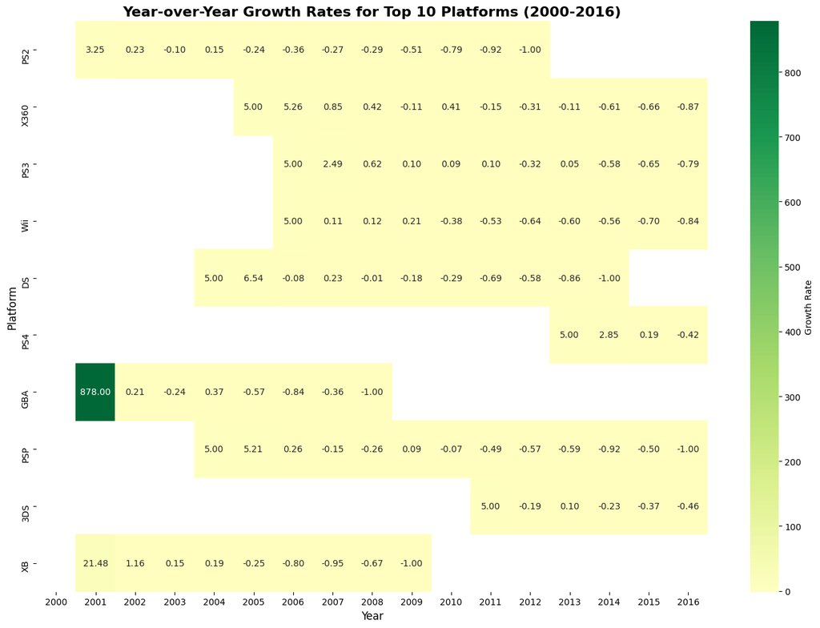

```python
plt.figure(figsize=(14, 10))
sns.heatmap(growth_data_clean,
           annot=True,
           fmt='.2f',
           cmap='RdYlGn',
           center=0,
           cbar_kws={'label': 'Growth Rate'},
           mask=growth_data_clean.isnull())  # This masks NaN values
plt.title('Year-over-Year Growth Rates for Top 10 Platforms (2000-2016)',
          fontsize=16, fontweight='bold')
plt.xlabel('Year', fontsize=12)
plt.ylabel('Platform', fontsize=12)
plt.tight_layout()
plt.show()# Your code here to calculate and visualize platform growth rates
```

## 3.5 Sales Distribution Analysis

Let's examine the distribution of sales across platforms:

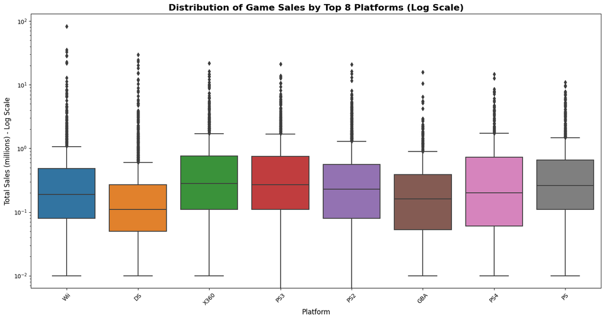

```python
top_platforms = games.groupby('platform')['total_sales'].sum().nlargest(8).index
top_platform_games = games[games['platform'].isin(top_platforms)]

plt.figure(figsize=(15, 8))
sns.boxplot(data=top_platform_games, x='platform', y='total_sales')
plt.yscale('log')  # This will help with the wide range
plt.title('Distribution of Game Sales by Top 8 Platforms (Log Scale)', fontsize=16, fontweight='bold')
plt.xlabel('Platform', fontsize=12)
plt.ylabel('Total Sales (millions) - Log Scale', fontsize=12)
plt.xticks(rotation=45)
plt.tight_layout()
plt.show()  #Create box plot of sales by platform
```

```python
top_platform_games.groupby('platform')['total_sales'].describe() # Calculate detailed statistics for each platform
```

| platform | count | mean | std | min | 25% | 50% | 75% | max |
| --- | --- | --- | --- | --- | --- | --- | --- | --- |
| DS | 2151.0 | 0.374765 | 1.426451 | 0.01 | 0.0500 | 0.11 | 0.2700 | 29.80 |
| GBA | 822.0 | 0.386679 | 0.896897 | 0.01 | 0.0525 | 0.16 | 0.3900 | 15.84 |
| PS | 1197.0 | 0.610576 | 1.054502 | 0.01 | 0.1100 | 0.26 | 0.6600 | 10.95 |
| PS2 | 2161.0 | 0.581106 | 1.137927 | 0.00 | 0.0800 | 0.23 | 0.5600 | 20.81 |
| PS3 | 1331.0 | 0.705973 | 1.391749 | 0.00 | 0.1100 | 0.27 | 0.7500 | 21.05 |
| PS4 | 392.0 | 0.801378 | 1.609456 | 0.01 | 0.0600 | 0.20 | 0.7300 | 14.63 |
| Wii | 1320.0 | 0.687508 | 3.126609 | 0.01 | 0.0800 | 0.19 | 0.4825 | 82.54 |
| X360 | 1262.0 | 0.769746 | 1.615674 | 0.01 | 0.1100 | 0.28 | 0.7575 | 21.82 |

```python
platform_stats = top_platform_games.groupby('platform').agg({
    'total_sales': ['count', 'mean', 'median', 'std', 'min', 'max', 'sum'],
    'critic_score': ['mean', 'median', 'count'],
    'user_score': ['count']
}).round(2)

print(platform_stats)
```

```
         total_sales                                          critic_score  \
               count  mean median   std   min    max      sum         mean
platform
DS              2151  0.37   0.11  1.43  0.01  29.80   806.12        63.76
GBA              822  0.39   0.16  0.90  0.01  15.84   317.85        67.37
PS              1197  0.61   0.26  1.05  0.01  10.95   730.86        71.52
PS2             2161  0.58   0.23  1.14  0.00  20.81  1255.77        68.73
PS3             1331  0.71   0.27  1.39  0.00  21.05   939.65        70.38
PS4              392  0.80   0.20  1.61  0.01  14.63   314.14        72.09
Wii             1320  0.69   0.19  3.13  0.01  82.54   907.51        62.82
X360            1262  0.77   0.28  1.62  0.01  21.82   971.42        68.62

                      user_score
         median count      count
platform
DS         66.0   717       1272
GBA        69.0   438        517
PS         73.5   200        207
PS2        70.0  1298       1481
PS3        73.0   820        964
PS4        73.0   252        263
Wii        65.0   585       1000
X360       71.0   916       1050
```

```python
consistency_stats = top_platform_games.groupby('platform')['total_sales'].agg([
    'mean',
    'std',
    lambda x: x.std() / x.mean()  # Coefficient of variation
]).round(3)

consistency_stats.columns = ['mean_sales', 'std_sales', 'coefficient_of_variation']
consistency_stats = consistency_stats.sort_values('coefficient_of_variation')
print("Platforms by sales consistency (lower = more consistent):")
print(consistency_stats)
```

```
Platforms by sales consistency (lower = more consistent):
          mean_sales  std_sales  coefficient_of_variation
platform
PS             0.611      1.055                     1.727
PS2            0.581      1.138                     1.958
PS3            0.706      1.392                     1.971
PS4            0.801      1.609                     2.008
X360           0.770      1.616                     2.099
GBA            0.387      0.897                     2.319
DS             0.375      1.426                     3.806
Wii            0.688      3.127                     4.548
```

```python
esrb_by_platform = top_platform_games.groupby(['platform', 'rating']).size().unstack(fill_value=0)
esrb_percentages = esrb_by_platform.div(esrb_by_platform.sum(axis=1), axis=0) * 100
print("ESRB Rating Distribution by Platform (%):")
print(esrb_percentages.round(1))
```

```
ESRB Rating Distribution by Platform (%):
rating       E  E10+   EC  K-A     M     T
platform
DS        68.8  20.3  0.2  0.0   0.8   9.9
GBA       81.6   4.8  0.0  0.0   1.3  12.3
PS        55.8   0.0  0.0  0.5   9.6  34.1
PS2       37.5   8.4  0.1  0.0  15.1  38.9
PS3       22.2  14.7  0.0  0.0  27.8  35.3
PS4       21.2  15.7  0.0  0.0  29.8  33.3
Wii       50.2  24.2  0.2  0.0   3.3  22.2
X360      23.5  16.0  0.0  0.0  27.9  32.6
```

Nintendo games are more "lighter" games, kid and family friendly - preferred genreas are sports, stimulation, role playing etc. Consoles like PS and XBox are for more adult content, higher sales in action/shooter genres.

## 3.6 Review Score Impact Analysis

Select a popular platform and analyze how reviews affect sales: Hypothesis - the higher the score, the higher the sales.

```python
#check the data to make sure its ready for visualization
ds_games = games[games['platform'] == 'DS'].copy()

print("DS games shape:", ds_games.shape)
print("User score data type:", ds_games['user_score'].dtype)
print("Sample user scores:", ds_games['user_score'].head(10))# Choose a popular platform based on your previous analysis
```

```
DS games shape: (2151, 12)
User score data type: object
Sample user scores: 6     8.5
10    NaN
11    8.6
19    7.9
20    NaN
26    7.1
27    NaN
43    8.7
46    NaN
59    NaN
Name: user_score, dtype: object
```

```python
#clean the data
ds_games['user_score_numeric'] = pd.to_numeric(ds_games['user_score'], errors='coerce')

print("User score conversion results:")
print("Original unique values:", ds_games['user_score'].unique()[:10])
print("Converted unique values:", ds_games['user_score_numeric'].unique()[:10])
print("NaN count after conversion:", ds_games['user_score_numeric'].isnull().sum())
```

```
User score conversion results:
Original unique values: ['8.5' nan '8.6' '7.9' '7.1' '8.7' '7.8' '7.4' '8.8' '7.2']
Converted unique values: [8.5 nan 8.6 7.9 7.1 8.7 7.8 7.4 8.8 7.2]
NaN count after conversion: 1635
```

```python
ds_clean = ds_games.dropna(subset=['critic_score', 'user_score_numeric', 'total_sales'])

print(f"Clean DS dataset: {len(ds_clean)} games (from {len(ds_games)} total)")
print(f"Percentage of games with complete review data: {len(ds_clean)/len(ds_games)*100:.1f}%")

# Check the data ranges
print("\nData ranges:")
print(f"Critic scores: {ds_clean['critic_score'].min():.1f} - {ds_clean['critic_score'].max():.1f}")
print(f"User scores: {ds_clean['user_score_numeric'].min():.1f} - {ds_clean['user_score_numeric'].max():.1f}")
print(f"Total sales: {ds_clean['total_sales'].min():.2f} - {ds_clean['total_sales'].max():.2f}")
```

```
Clean DS dataset: 469 games (from 2151 total)
Percentage of games with complete review data: 21.8%

Data ranges:
Critic scores: 19.0 - 93.0
User scores: 1.7 - 9.3
Total sales: 0.01 - 29.80
```

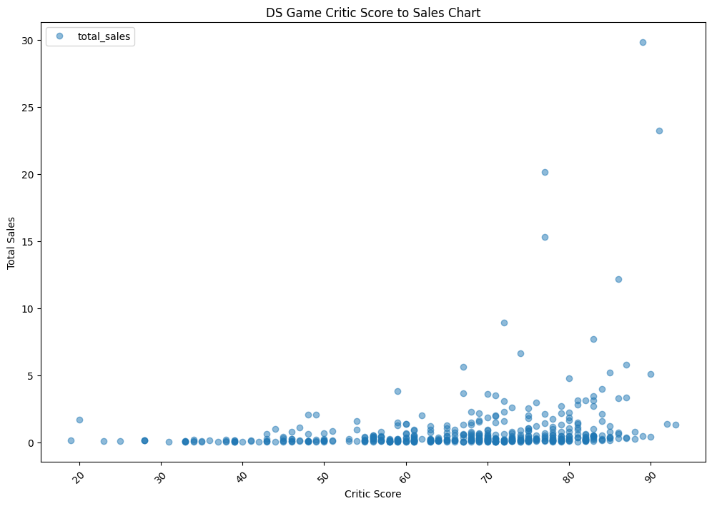

```python
ds_clean.plot(style='o',
              x = 'critic_score',
              y = 'total_sales',
              xlabel = 'Critic Score',
              ylabel = 'Total Sales',
              title = "DS Game Critic Score to Sales Chart",
              rot = 45,
              alpha = 0.5,
              figsize = (12,8))
plt.show()# Create scatter plots for both critic and user scores
```

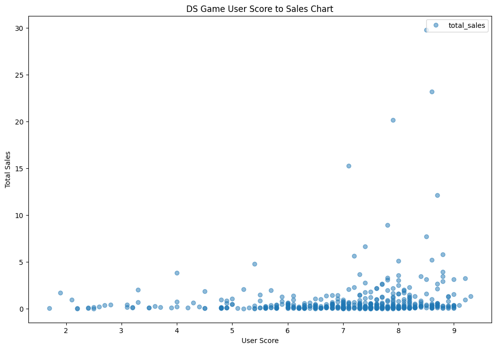

```python
ds_sorted = ds_clean.sort_values('user_score_numeric')

ds_sorted.plot(style='o',
               x='user_score_numeric',
               y='total_sales',
               xlabel='User Score',
               ylabel='Total Sales',
               title="DS Game User Score to Sales Chart",
               alpha=0.5,
               figsize=(12,8))
plt.show()# User Scores
```

```python
correlation_matrix = ds_clean[['critic_score', 'user_score_numeric', 'total_sales']].corr()
print("DS Review to Sales Correlation:")
print(correlation_matrix)
```

```
DS Review to Sales Correlation:
                    critic_score  user_score_numeric  total_sales
critic_score            1.000000            0.655516     0.230941
user_score_numeric      0.655516            1.000000     0.139453
total_sales             0.230941            0.139453     1.000000
```

Results show that consumers dont go off of reviews when purchasing a game - proving my hypothesis incorrect. Critic scores and user scores show moderate positive correlation - showing that users do generally agree with critic reviews. Critis scores have a slight higher correlation from their score/sale ratio - consumers trust a critic review more than a regular consumer. Other factors may have higher correlation to sales i.e. game history (is this the second or third game from the series), marketing done by the platform, promotions etc. With the ESRB being primarily rated E - could these review/score factors change for more mature/adult platforms?

## 3.7 Cross-Platform Comparison

Compare sales performance of games across different platforms:

```python
gaming_platforms = games.groupby('name')['platform'].nunique()
multi_platform_games = gaming_platforms[gaming_platforms >= 3]
multi_platform_games
# Find games released on multiple platforms
```

```
name
007: Quantum of Solace              6
2002 FIFA World Cup                 3
2010 FIFA World Cup South Africa    4
428: Fuusa Sareta Shibuya de        3
50 Cent: Bulletproof                3
                                   ..
ZombiU                              3
Zumba Fitness                       3
[Prototype 2]                       3
de Blob 2                           4
pro evolution soccer 2011           6
Name: platform, Length: 1283, dtype: int64
```

```python
multi_platform_data = games[games['name'].isin(multi_platform_games.index)]
multi_platform_data
```

|  | name | platform | year_of_release | genre | na_sales | eu_sales | jp_sales | other_sales | critic_score | user_score | rating | total_sales |
| --- | --- | --- | --- | --- | --- | --- | --- | --- | --- | --- | --- | --- |
| 16 | Grand Theft Auto V | PS3 | 2013 | Action | 7.02 | 9.09 | 0.98 | 3.96 | 97.0 | 8.2 | M | 21.05 |
| 17 | Grand Theft Auto: San Andreas | PS2 | 2004 | Action | 9.43 | 0.40 | 0.41 | 10.57 | 95.0 | 9 | M | 20.81 |
| 23 | Grand Theft Auto V | X360 | 2013 | Action | 9.66 | 5.14 | 0.06 | 1.41 | 97.0 | 8.1 | M | 16.27 |
| 29 | Call of Duty: Modern Warfare 3 | X360 | 2011 | Shooter | 9.04 | 4.24 | 0.13 | 1.32 | 88.0 | 3.4 | M | 14.73 |
| 31 | Call of Duty: Black Ops 3 | PS4 | 2015 | Shooter | 6.03 | 5.86 | 0.36 | 2.38 | NaN | NaN | NaN | 14.63 |
| ... | ... | ... | ... | ... | ... | ... | ... | ... | ... | ... | ... | ... |
| 16690 | Pony Friends 2 | PC | 2009 | Simulation | 0.00 | 0.01 | 0.00 | 0.00 | NaN | NaN | NaN | 0.01 |
| 16691 | Dynasty Warriors: Eiketsuden | PS3 | 2016 | Action | 0.00 | 0.00 | 0.01 | 0.00 | NaN | NaN | NaN | 0.01 |
| 16692 | Metal Gear Solid V: Ground Zeroes | PC | 2014 | Action | 0.00 | 0.01 | 0.00 | 0.00 | 80.0 | 7.6 | M | 0.01 |
| 16709 | SCORE International Baja 1000: The Official Game | PS2 | 2008 | Racing | 0.00 | 0.00 | 0.00 | 0.00 | NaN | NaN | NaN | 0.00 |
| 16710 | Samurai Warriors: Sanada Maru | PS3 | 2016 | Action | 0.00 | 0.00 | 0.01 | 0.00 | NaN | NaN | NaN | 0.01 |

4915 rows × 12 columns

```python
game_platform_sales = multi_platform_data.groupby(['name', 'platform'])['total_sales'].sum()
game_platform_sales# Compare sales across platforms for these games
```

```
name                       platform
007: Quantum of Solace     DS          0.13
                           PC          0.02
                           PS2         0.43
                           PS3         1.15
                           Wii         0.65
                                       ...
pro evolution soccer 2011  PS2         0.41
                           PS3         2.41
                           PSP         0.80
                           Wii         0.22
                           X360        0.60
Name: total_sales, Length: 4911, dtype: float64
```

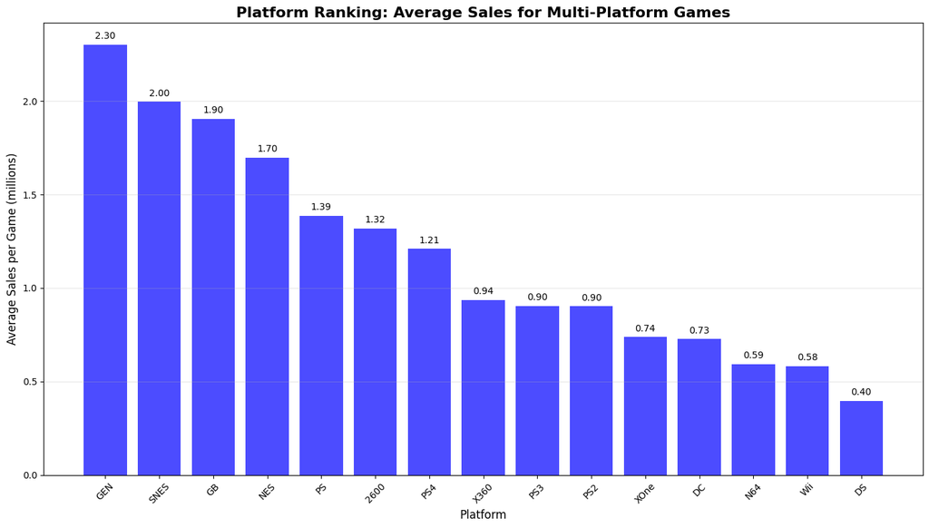

```python
game_platform_df = game_platform_sales.reset_index()
platform_avg_performance = game_platform_df.groupby('platform')['total_sales'].agg(['mean', 'median', 'count']).round(3)
platform_avg_performance = platform_avg_performance.sort_values('mean', ascending=False)
plt.figure(figsize=(14, 8))

# Get the top 15 platforms by mean sales for better readability
top_15_platforms = platform_avg_performance.head(15)

# Create the bar chart
bars = plt.bar(range(len(top_15_platforms)),
               top_15_platforms['mean'],
               color='blue',
               alpha=0.7)

# Customize the chart
plt.title('Platform Ranking: Average Sales for Multi-Platform Games',
          fontsize=16, fontweight='bold')
plt.xlabel('Platform', fontsize=12)
plt.ylabel('Average Sales per Game (millions)', fontsize=12)
plt.xticks(range(len(top_15_platforms)), top_15_platforms.index, rotation=45)

# Add value labels on top of bars
for i, bar in enumerate(bars):
    height = bar.get_height()
    plt.text(bar.get_x() + bar.get_width()/2., height + 0.02,
             f'{height:.2f}', ha='center', va='bottom', fontsize=10)

plt.grid(axis='y', alpha=0.3)
plt.tight_layout()
plt.show()# visualize cross-platform performance
```

## 3.8 Genre Analysis

Finally, let's examine the distribution of games by genre:

```python
genre_performance = games.groupby('genre')['total_sales'].agg(['sum', 'mean', 'median', 'count']).round(3)
# Analyze genre performance
```

```python
genre_performance = genre_performance.sort_values('sum', ascending=False)
print("Genre Performance Summary:")
print(genre_performance)# Sort genres by total sales
```

```
Genre Performance Summary:
                  sum   mean  median  count
genre
Action        1744.17  0.518    0.19   3369
Sports        1331.27  0.567    0.22   2348
Shooter       1052.45  0.796    0.24   1323
Role-Playing   934.56  0.624    0.18   1498
Platform       827.77  0.932    0.27    888
Misc           802.51  0.459    0.16   1750
Racing         728.67  0.583    0.19   1249
Fighting       447.53  0.527    0.21    849
Simulation     389.97  0.447    0.15    873
Puzzle         242.57  0.418    0.11    580
Adventure      237.59  0.182    0.05   1303
Strategy       174.23  0.255    0.10    683
```

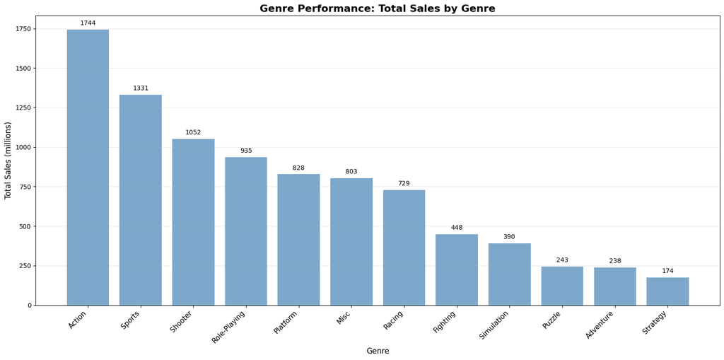

```python
plt.figure(figsize=(16, 8))  # Made figure wider

bars = plt.bar(range(len(genre_performance)),
               genre_performance['sum'],
               color='steelblue',
               alpha=0.7,
               width=0.8)
# Customize the chart
plt.title('Genre Performance: Total Sales by Genre',
          fontsize=16, fontweight='bold')
plt.xlabel('Genre', fontsize=12)
plt.ylabel('Total Sales (millions)', fontsize=12)

plt.xticks(range(len(genre_performance)),
           genre_performance.index,
           rotation=45,
           ha='right',
           fontsize=11)

# Add value labels on top of bars
for i, bar in enumerate(bars):
    height = bar.get_height()
    plt.text(bar.get_x() + bar.get_width()/2., height + 20,
             f'{height:.0f}', ha='center', va='bottom', fontsize=10)

plt.grid(axis='y', alpha=0.3)
plt.tight_layout()  # This helps prevent label cutoff
plt.show()# Visualize genre distribution
```

```python
# Calculate total market size (sum of all genre sales)
total_market = genre_performance['sum'].sum()
print(f"Total market size: {total_market:.2f} million")

# Calculate market share for each genre
genre_performance['market_share'] = (genre_performance['sum'] / total_market * 100).round(2)

# Display the results
print("\nGenre Market Share Analysis:")
print(genre_performance[['sum', 'market_share']].head(10))# Calculate market share for each genre
```

```
Total market size: 8913.29 million

Genre Market Share Analysis:
                  sum  market_share
genre
Action        1744.17         19.57
Sports        1331.27         14.94
Shooter       1052.45         11.81
Role-Playing   934.56         10.49
Platform       827.77          9.29
Misc           802.51          9.00
Racing         728.67          8.18
Fighting       447.53          5.02
Simulation     389.97          4.38
Puzzle         242.57          2.72
```

```python
#Are there any genres showing recent growth or decline?
genre_yearly_sales = games.groupby(['year_of_release', 'genre'])['total_sales'].sum()
recent_years = games[games['year_of_release'].between(2012, 2016)]

genre_pivot = recent_years.pivot_table(
    values='total_sales',
    index='genre',
    columns='year_of_release',
    aggfunc='sum',
    fill_value=0
)

print("Genre Sales by Year (2012-2016):")
print(genre_pivot)
```

```
Genre Sales by Year (2012-2016):
year_of_release    2012    2013   2014   2015   2016
genre
Action           119.25  122.51  97.23  72.02  30.11
Adventure          5.79    6.09   5.57   8.16   3.82
Fighting           9.18    7.09  15.85   7.90   4.47
Misc              22.22   25.27  23.38  11.57   2.60
Platform          18.37   24.54   8.81   6.05   3.23
Puzzle             1.72    0.96   1.49   0.71   0.01
Racing            13.61   12.37  16.66   8.07   2.79
Role-Playing      46.91   44.45  45.62  37.64  18.18
Shooter           71.75   62.04  65.21  67.51  38.22
Simulation        13.36    8.63   5.58   5.66   1.89
Sports            30.42   41.17  45.15  40.84  23.49
Strategy           3.26    6.12   0.98   1.85   1.13
```

### Key Questions for Genre Analysis:

- Which genres consistently perform well? -- action - they have most sales and games total sold across platforms
- Are there any genres showing recent growth or decline? -- looking over the last 5 years, it seems all genres had a decline in sales - action, having the highest sales, had a tremendous decline in sales from the last 5 years, almost 100 M drop.
- How does the average performance vary across genres? -- acation leads in total sales but has a moderage average per game (0.5M), platform games have the highest acerage sakes per game (.9 M) despoite fewer total games, and adventure has the lowest average performance (.18 M per game).

**Reviewer's comment v1:**

Well done! The graphs used are correct, as are the conclusions of the section.

# Step 4: Regional Market Analysis and User Profiles

In this section, we will analyze the gaming market characteristics across three major regions: North America (NA), Europe (EU), and Japan (JP). Our analysis will focus on platform preferences, genre popularity, and the impact of ESRB ratings in each region.

## 4.1 Regional Platform Analysis

Let's begin by examining platform performance across different regions:

```python
def analyze_platform_performance_by_region(data, top_n=10):
    """
    Analyze platform performance broken down by region
    Returns total sales for each platform organized by region from highest to lowest
    """
    platform_regional = data.groupby('platform')[['na_sales', 'eu_sales', 'jp_sales', 'other_sales']].sum()
    platform_regional['total_sales'] = platform_regional.sum(axis=1)
    platform_regional_sorted = platform_regional.sort_values(by='total_sales', ascending=False)
    top_platforms = platform_regional_sorted.head(top_n)

    sales_pivot = data.pivot_table(
        values=['na_sales', 'eu_sales', 'jp_sales', 'other_sales'],
        index='platform',
        aggfunc='sum'
    )

    # Create pivot table for game count by region
    count_pivot = data.pivot_table(
        values=['na_sales', 'eu_sales', 'jp_sales', 'other_sales'],
        index='platform',
        aggfunc='count'
    )

    # Filter to top N platforms and sort by total sales
    top_platform_names = top_platforms.index
    sales_pivot_top = sales_pivot.loc[top_platform_names]
    count_pivot_top = count_pivot.loc[top_platform_names]

    return sales_pivot_top, count_pivot_top

# Function to analyze platform performance by region
```

**Reviewer's comment v1:**

Like in most of the previous section, you should continue working with the data from the time period you chose.

This affects this section and the following ones since it is likely that your hypotheses will change, and with them, the final conclusions.

**Reviewer's comment v2**

Well done!

```python
sales_table, count_table = analyze_platform_performance_by_region(games, top_n=10)

print("Platform Sales by Region (Top 10):")
print(sales_table.round(2))

print("\nPlatform Game Count by Region (Top 10):")
print(count_table)# Analyze each region
```

```
Platform Sales by Region (Top 10):
          eu_sales  jp_sales  na_sales  other_sales
platform
PS2         339.29    139.20    583.84       193.44
X360        270.76     12.43    602.47        85.76
PS3         330.29     80.19    393.49       135.68
Wii         262.21     69.33    496.90        79.07
DS          188.89    175.57    382.40        59.26
PS          213.61    139.82    336.52        40.91
GBA          75.25     47.33    187.54         7.73
PS4         141.09     15.96    108.74        48.35
PSP          66.68     76.78    109.17        41.42
PC          142.44      0.17     94.53        22.38

Platform Game Count by Region (Top 10):
          eu_sales  jp_sales  na_sales  other_sales
platform
PS2           2161      2161      2161         2161
X360          1262      1262      1262         1262
PS3           1331      1331      1331         1331
Wii           1320      1320      1320         1320
DS            2151      2151      2151         2151
PS            1197      1197      1197         1197
GBA            822       822       822          822
PS4            392       392       392          392
PSP           1209      1209      1209         1209
PC             974       974       974          974
```

### Cross-Regional Platform Comparison

Let's create a comparative analysis of platform performance across regions:

```python
def comparative_platform_analysis_by_region(data, start_year=2000, top_n=5):
    """
    Create comparative analysis of platform performance across regions
    Returns top platforms for each region with both sales volume and market share analysis
    """
    # Filter to recent years (last 5 years)
    recent_data = data[data['year_of_release'] >= start_year].copy()

    # Calculate total sales by platform for each region
    regional_analysis = {}
    regions = ['na_sales', 'eu_sales', 'jp_sales', 'other_sales']
    region_names = ['North America', 'Europe', 'Japan', 'Other']

    for region, region_name in zip(regions, region_names):
        # Group by platform and sum sales for this region
        platform_sales = recent_data.groupby('platform')[region].sum().sort_values(ascending=False)

        # Calculate market share percentages
        total_regional_sales = platform_sales.sum()
        market_share = (platform_sales / total_regional_sales * 100).round(2)

        # Get top N platforms
        top_platforms = platform_sales.head(top_n)
        top_market_share = market_share.head(top_n)

        regional_analysis[region_name] = {
            'sales': top_platforms,
            'market_share': top_market_share,
            'total_sales': total_regional_sales
        }

    return regional_analysis

# Call the function
regional_results = comparative_platform_analysis_by_region(games, start_year=2000, top_n=5)

# Display results for each region
for region, data in regional_results.items():
    print(f"\n=== {region.upper()} ===")
    print(f"Total Regional Sales (2000-2016): {data['total_sales']:.2f} million")
    print(f"\nTop 5 Platforms by Sales Volume:")
    for i, (platform, sales) in enumerate(data['sales'].items(), 1):
        market_share = data['market_share'][platform]
        print(f"{i}. {platform}: {sales:.2f}M ({market_share}%)")# Create a comparative platform analysis
```

```
=== NORTH AMERICA ===
Total Regional Sales (2000-2016): 3529.61 million

Top 5 Platforms by Sales Volume:
1. X360: 595.74M (16.88%)
2. PS2: 572.92M (16.23%)
3. Wii: 486.87M (13.79%)
4. PS3: 390.13M (11.05%)
5. DS: 380.31M (10.77%)

=== EUROPE ===
Total Regional Sales (2000-2016): 2085.61 million

Top 5 Platforms by Sales Volume:
1. PS2: 332.63M (15.95%)
2. PS3: 327.21M (15.69%)
3. X360: 268.32M (12.87%)
4. Wii: 258.32M (12.39%)
5. DS: 188.41M (9.03%)

=== JAPAN ===
Total Regional Sales (2000-2016): 815.82 million

Top 5 Platforms by Sales Volume:
1. DS: 175.00M (21.45%)
2. PS2: 137.54M (16.86%)
3. 3DS: 100.62M (12.33%)
4. PS3: 79.41M (9.73%)
5. PSP: 75.88M (9.3%)

=== OTHER ===
Total Regional Sales (2000-2016): 728.11 million

Top 5 Platforms by Sales Volume:
1. PS2: 190.47M (26.16%)
2. PS3: 134.59M (18.48%)
3. X360: 84.88M (11.66%)
4. Wii: 77.71M (10.67%)
5. DS: 59.04M (8.11%)
```

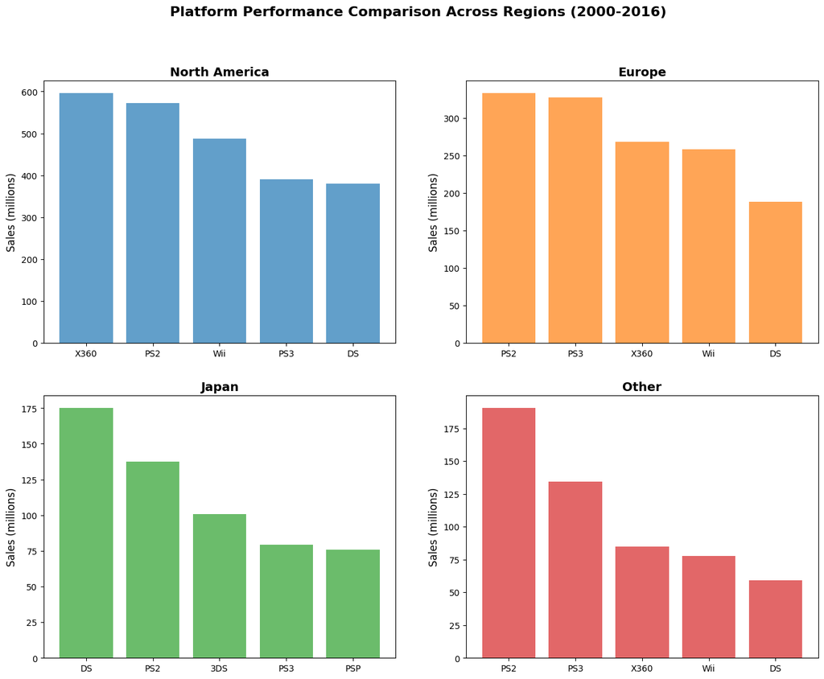

```python
# Create comparison visualization
import matplotlib.pyplot as plt
import numpy as np

fig, ((ax1, ax2), (ax3, ax4)) = plt.subplots(2, 2, figsize=(16, 12))
fig.suptitle('Platform Performance Comparison Across Regions (2000-2016)', fontsize=16, fontweight='bold')

regions = ['North America', 'Europe', 'Japan', 'Other']
axes = [ax1, ax2, ax3, ax4]

for i, (region, ax) in enumerate(zip(regions, axes)):
    data = regional_results[region]
    platforms = list(data['sales'].index)
    sales = list(data['sales'].values)
    market_shares = [data['market_share'] for p in platforms]

    # Create bar chart
    bars = ax.bar(platforms, sales, alpha=0.7, color=f'C{i}')
    ax.set_title(f'{region}', fontsize=14, fontweight='bold')
    ax.set_ylabel('Sales (millions)', fontsize=12)# Visualize cross-regional comparison for top platforms
```

## 4.2 Regional Genre Analysis

Now let's examine genre preferences across regions:

```python
def analyze_genre_by_region(data, genre_name, start_year=2000):
    """
    Analyze a specific genre's performance across all regions for the last 5 years
    """
    # Filter data for the specific genre and time period
    genre_data = data[(data['genre'] == genre_name) &
                     (data['year_of_release'] >= start_year)].copy()

    if len(genre_data) == 0:
        print(f"No data found for {genre_name} genre in the specified period")
        return None

    # Regional analysis
    regional_sales = {
        'North America': genre_data['na_sales'].sum(),
        'Europe': genre_data['eu_sales'].sum(),
        'Japan': genre_data['jp_sales'].sum(),
        'Other': genre_data['other_sales'].sum()
    }

    # Calculate total sales and market share
    total_sales = sum(regional_sales.values())
    market_share = {region: (sales/total_sales*100) if total_sales > 0 else 0
                   for region, sales in regional_sales.items()}

    # Game count by region (all regions have same count)
    game_count = len(genre_data)

    # Average sales per game by region
    avg_sales = {region: sales/game_count if game_count > 0 else 0
                for region, sales in regional_sales.items()}

    # Year-over-year analysis
    yearly_sales = genre_data.groupby('year_of_release')[['na_sales', 'eu_sales', 'jp_sales', 'other_sales']].sum()

    return {
        'genre': genre_name,
        'total_sales': total_sales,
        'game_count': game_count,
        'regional_sales': regional_sales,
        'market_share': market_share,
        'avg_sales_per_game': avg_sales,
        'yearly_trends': yearly_sales
    }

# Get all unique genres
all_genres = games['genre'].dropna().unique()
print(f"All genres to analyze: {sorted(all_genres)}")
print(f"Total genres: {len(all_genres)}")# Function to analyze genre performance by region
```

```
All genres to analyze: ['Action', 'Adventure', 'Fighting', 'Misc', 'Platform', 'Puzzle', 'Racing', 'Role-Playing', 'Shooter', 'Simulation', 'Sports', 'Strategy']
Total genres: 12
```

```python
# Analyze all genres
genre_analyses = {}

for genre in sorted(all_genres):
    print(f"\n{'='*60}")
    print(f"ANALYZING: {genre.upper()} GENRE")
    print(f"{'='*60}")

    analysis = analyze_genre_by_region(games, genre, start_year=2000)

    if analysis:
        genre_analyses[genre] = analysis

        print(f"Total Sales (2000-2016): {analysis['total_sales']:.2f} million")
        print(f"Number of Games: {analysis['game_count']}")
        print(f"Average Sales per Game: {analysis['total_sales']/analysis['game_count']:.3f} million")

        print(f"\nRegional Breakdown:")
        print(f"{'Region':<15} {'Sales (M)':<12} {'Market Share':<12} {'Avg per Game':<12}")
        print("-" * 55)

        for region in ['North America', 'Europe', 'Japan', 'Other']:
            sales = analysis['regional_sales']
```

```
============================================================
ANALYZING: ACTION GENRE
============================================================
Total Sales (2000-2016): 1526.16 million
Number of Games: 3079
Average Sales per Game: 0.496 million

Regional Breakdown:
Region          Sales (M)    Market Share Avg per Game
-------------------------------------------------------

============================================================
ANALYZING: ADVENTURE GENRE
============================================================
Total Sales (2000-2016): 183.74 million
Number of Games: 1194
Average Sales per Game: 0.154 million

Regional Breakdown:
Region          Sales (M)    Market Share Avg per Game
-------------------------------------------------------

============================================================
ANALYZING: FIGHTING GENRE
============================================================
Total Sales (2000-2016): 311.90 million
Number of Games: 640
Average Sales per Game: 0.487 million

Regional Breakdown:
Region          Sales (M)    Market Share Avg per Game
-------------------------------------------------------

============================================================
ANALYZING: MISC GENRE
============================================================
Total Sales (2000-2016): 718.35 million
Number of Games: 1597
Average Sales per Game: 0.450 million

```

[output cut: 76 more lines]

```

Regional Breakdown:
Region          Sales (M)    Market Share Avg per Game
-------------------------------------------------------

============================================================
ANALYZING: STRATEGY GENRE
============================================================
Total Sales (2000-2016): 115.07 million
Number of Games: 550
Average Sales per Game: 0.209 million

Regional Breakdown:
Region          Sales (M)    Market Share Avg per Game
-------------------------------------------------------
```

### Cross-Regional Genre Comparison

Let's compare genre preferences across regions:

```python
def create_genre_comparison_matrix(data, start_year=2000):
    """
    Create a comparison matrix showing all genres across all regions
    """
    # Filter to recent years
    recent_data = data[data['year_of_release'] >= start_year].copy()

    # Create pivot table for regional sales by genre
    genre_regional = recent_data.groupby('genre')[['na_sales', 'eu_sales', 'jp_sales', 'other_sales']].sum()

    # Calculate total sales and market share for each genre
    genre_regional['total_sales'] = genre_regional.sum(axis=1)
    genre_regional['market_share'] = (genre_regional['total_sales'] / genre_regional['total_sales'].sum() * 100).round(2)

    # Sort by total sales
    genre_regional = genre_regional.sort_values('total_sales', ascending=False)

    return genre_regional

# Create the comparison matrix
genre_comparison = create_genre_comparison_matrix(games, start_year=2000)
print("COMPREHENSIVE GENRE COMPARISON (2000-2016)")
print("=" * 70)
print(genre_comparison.round(2))# Create a comparative genre analysis
```

```
COMPREHENSIVE GENRE COMPARISON (2000-2016)
======================================================================
              na_sales  eu_sales  jp_sales  other_sales  total_sales  \
genre
Action          752.27    466.58    132.23       175.08      1526.16
Sports          589.39    339.58     75.88       126.07      1130.92
Shooter         495.23    294.02     23.28       100.17       912.70
Role-Playing    282.30    155.69    241.71        51.52       731.22
Misc            365.27    196.71     85.43        70.94       718.35
Racing          272.31    192.02     27.74        68.99       561.06
Platform        257.55    140.00     55.27        41.60       494.42
Simulation      162.17    104.70     40.16        28.38       335.41
Fighting        160.77     74.51     44.89        31.73       311.90
Adventure        82.13     49.50     37.34        14.77       183.74
Puzzle           64.15     39.75     24.18        10.12       138.20
Strategy         46.07     32.55     27.71         8.74       115.07

              market_share
genre
Action               21.32
Sports               15.80
Shooter              12.75
Role-Playing         10.21
Misc                 10.03
Racing                7.84
Platform              6.91
Simulation            4.69
Fighting              4.36
Adventure             2.57
Puzzle                1.93
Strategy              1.61
```

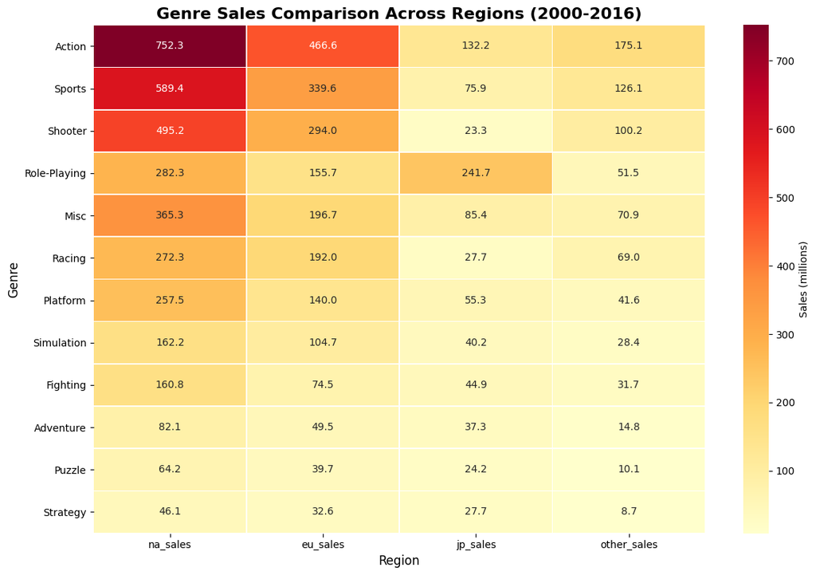

```python
# Create a comprehensive visualization comparing genres across regions
plt.figure(figsize=(12, 8))
sns.heatmap(genre_comparison[['na_sales', 'eu_sales', 'jp_sales', 'other_sales']],
            annot=True,
            fmt='.1f',
            cmap='YlOrRd',
            cbar_kws={'label': 'Sales (millions)'},
            linewidths=0.5)
plt.title('Genre Sales Comparison Across Regions (2000-2016)',
          fontsize=16, fontweight='bold')
plt.xlabel('Region', fontsize=12)
plt.ylabel('Genre', fontsize=12)
plt.tight_layout()
plt.show()
```

## 4.3 ESRB Rating Impact Analysis

Finally, let's examine how ESRB ratings affect sales in each region:

```python
def analyze_esrb_rating_impact(data, start_year=2000):
    """
    Analyze how ESRB ratings affect sales across different regions
    """
    # Filter to recent years and remove games without ratings
    recent_data = data[(data['year_of_release'] >= start_year) &
                       (data['rating'].notna())].copy()

    # Group by ESRB rating and calculate regional sales
    rating_analysis = recent_data.groupby('rating')[['na_sales', 'eu_sales', 'jp_sales', 'other_sales']].agg(['sum', 'mean', 'count'])

    return rating_analysis

# Test the function
esrb_results = analyze_esrb_rating_impact(games, start_year=2000)
# Function to analyze ESRB rating impact
```

```python
print("ESRB Rating Impact Analysis (2000-2016)")
print("=" * 60)
print(esrb_results.round(3))# Analyze ESRB impact for each region
```

```
ESRB Rating Impact Analysis (2000-2016)
============================================================
       na_sales              eu_sales              jp_sales               \
            sum   mean count      sum   mean count      sum   mean count
rating
AO         1.26  1.260     1     0.61  0.610     1     0.00  0.000     1
E       1249.26  0.322  3881   690.61  0.178  3881   189.91  0.049  3881
E10+     345.50  0.248  1392   183.33  0.132  1392    40.20  0.029  1392
EC         1.53  0.191     8     0.11  0.014     8     0.00  0.000     8
M        727.80  0.479  1521   472.40  0.311  1521    57.84  0.038  1521
RP         0.00  0.000     1     0.03  0.030     1     0.00  0.000     1
T        709.86  0.248  2859   392.71  0.137  2859   131.01  0.046  2859

       other_sales
               sum   mean count
rating
AO            0.09  0.090     1
E           229.38  0.059  3881
E10+         71.92  0.052  1392
EC            0.11  0.014     8
M           174.31  0.115  1521
RP            0.01  0.010     1
T           148.20  0.052  2859
```

**Reviewer's comment v2**

The analyses of each section were correct

# Step 5 : Hypothesis Tests

## Average user ratings of the Xbox One and PC platforms are the same.

**Reviewer's comment v2:**

Like in most of the previous section, you should continue working with the data from the time period you chose.

This affects this section and with it, the final conclusions.

```python
filtered_games = games[games['year_of_release'].between(2000,2016)]
xbox_data = filtered_games[filtered_games['platform'] == 'XOne']['user_score']
pc_data = filtered_games[filtered_games['platform'] == 'PC']['user_score']

print("Raw data overview:")
print(f"Xbox One user scores: {len(xbox_data)} total")
print(f"PC user scores: {len(pc_data)} total")
```

```
Raw data overview:
Xbox One user scores: 247 total
PC user scores: 917 total
```

```python
# First, let's examine the user_score column
print("User score data types and sample values:")
print(f"Data type: {filtered_games['user_score'].dtype}")
print(f"Unique values sample: {filtered_games['user_score'].unique()[:10]}")
print(f"Total NaN values: {filtered_games['user_score'].isna().sum()}")

xbox_data = filtered_games[filtered_games['platform'] == 'XOne'].copy()
pc_data = filtered_games[filtered_games['platform'] == 'PC'].copy()

print("Before cleaning:")
print(f"Xbox One total games: {len(xbox_data)}")
print(f"PC total games: {len(pc_data)}")
```

```
User score data types and sample values:
Data type: object
Unique values sample: ['8' '8.3' '8.5' '6.6' '8.4' nan '8.6' '7.7' '6.3' '7.4']
Total NaN values: 4732
Before cleaning:
Xbox One total games: 247
PC total games: 917
```

```python
# Convert user_score to numeric and drop NaN values
xbox_clean = filtered_games[filtered_games['platform'] == 'XOne'].copy()
pc_clean = filtered_games[filtered_games['platform'] == 'PC'].copy()

# Convert to numeric (handles 'tbd' and other non-numeric values)
xbox_clean['user_score_numeric'] = pd.to_numeric(xbox_clean['user_score'], errors='coerce')
pc_clean['user_score_numeric'] = pd.to_numeric(pc_clean['user_score'], errors='coerce')

# Drop rows with NaN user scores
xbox_clean = xbox_clean.dropna(subset=['user_score_numeric'])
pc_clean = pc_clean.dropna(subset=['user_score_numeric'])

print("After cleaning:")
print(f"Xbox One games with valid user scores: {len(xbox_clean)}")
print(f"PC games with valid user scores: {len(pc_clean)}")
```

```
After cleaning:
Xbox One games with valid user scores: 182
PC games with valid user scores: 734
```

```python
xbox_avg = xbox_clean['user_score_numeric'].mean()
pc_avg = pc_clean['user_score_numeric'].mean()

print(f"\nAverage user ratings:")
print(f"Xbox One: {xbox_avg:.2f}")
print(f"PC: {pc_avg:.2f}")
print(f"Difference: {abs(xbox_avg - pc_avg):.2f}")
```

```
Average user ratings:
Xbox One: 6.52
PC: 7.03
Difference: 0.51
```

```python
# Extract the clean user score data
xbox_scores = xbox_clean['user_score_numeric']
pc_scores = pc_clean['user_score_numeric']

# Perform Welch's t-test (assumes unequal variances)
from scipy import stats
t_statistic, p_value = stats.ttest_ind(xbox_scores, pc_scores, equal_var=False)

print("Hypothesis Test Results:")
print(f"Sample sizes: Xbox One = {len(xbox_scores)}, PC = {len(pc_scores)}")
print(f"Sample means: Xbox One = {xbox_scores.mean():.3f}, PC = {pc_scores.mean():.3f}")
```

```
Hypothesis Test Results:
Sample sizes: Xbox One = 182, PC = 734
Sample means: Xbox One = 6.521, PC = 7.034
```

```python
print(f"t-statistic: {t_statistic:.4f}")
print(f"p-value: {p_value:.6f}")
print(f"Alpha level: 0.05")

# Interpret the results
if p_value < 0.05:
    print("Result: Reject the null hypothesis")
    print("Conclusion: Xbox One and PC platforms have significantly different average user ratings")
else:
    print("Result: Fail to reject the null hypothesis")
    print("Conclusion: No significant difference between Xbox One and PC platform ratings")
```

```
t-statistic: -4.3909
p-value: 0.000016
Alpha level: 0.05
Result: Reject the null hypothesis
Conclusion: Xbox One and PC platforms have significantly different average user ratings
```

**How you formulated the null and alternative hypotheses.** - they have a .51 difference which is pretty large in terms of being considered the "same".

**What criteria you used to test the hypotheses and why.** - i calculated the means of the platform user scores, and called 5% to our alpha for the chance of incorrectly rejecting a true null hypothesis.

**Reviewer's comment v3:**

Hypothesis testing looking good!

## Average user ratings for the Action and Sports genres are different.**

```python
action_data = filtered_games[filtered_games['genre'] == 'Action']['user_score']
sports_data = filtered_games[filtered_games['genre'] == 'Sports']['user_score']

print("Raw data overview:")
print(f"Action user scores: {len(action_data)} total")
print(f"Sports user scores: {len(sports_data)} total")
```

```
Raw data overview:
Action user scores: 3079 total
Sports user scores: 1979 total
```

```python
action_clean = filtered_games[filtered_games['genre'] == 'Action'].copy()
sports_clean = filtered_games[filtered_games['genre'] == 'Sports'].copy()

action_clean['user_score_numeric'] = pd.to_numeric(action_clean['user_score'], errors='coerce')
sports_clean['user_score_numeric'] = pd.to_numeric(sports_clean['user_score'], errors='coerce')

# Drop NaN values
action_clean = action_clean.dropna(subset=['user_score_numeric'])
sports_clean = sports_clean.dropna(subset=['user_score_numeric'])
```

```python
action_avg = action_clean['user_score_numeric'].mean()
sports_avg = sports_clean['user_score_numeric'].mean()

print(f"\nAverage user ratings:")
print(f"Action: {action_avg:.2f}")
print(f"Sports: {sports_avg:.2f}")
print(f"Difference: {abs(action_avg - sports_avg):.2f}")
```

```
Average user ratings:
Action: 7.05
Sports: 6.95
Difference: 0.10
```

```python
# Extract the clean user score data
action_scores = action_clean['user_score_numeric']
sports_scores = sports_clean['user_score_numeric']

# Perform Welch's t-test (assumes unequal variances)
from scipy import stats
t_statistic, p_value = stats.ttest_ind(action_scores, sports_scores, equal_var=False)

print("Hypothesis Test Results:")
print(f"Sample sizes: Action = {len(action_scores)}, Sports = {len(sports_scores)}")
print(f"Sample means: Action = {action_scores.mean():.3f}, Sports = {sports_scores.mean():.3f}")
```

```
Hypothesis Test Results:
Sample sizes: Action = 1781, Sports = 1079
Sample means: Action = 7.046, Sports = 6.948
```

```python
print(f"t-statistic: {t_statistic:.4f}")
print(f"p-value: {p_value:.6f}")
print(f"Alpha level: 0.05")

# Interpret the results
if p_value < 0.05:
    print("Result: Reject the null hypothesis")
    print("Conclusion: Action and Sports genres have significantly different average user ratings")
else:
    print("Result: Fail to reject the null hypothesis")
    print("Conclusion: No significant difference between Action and Sports genre ratings")
```

```
t-statistic: 1.6400
p-value: 0.101151
Alpha level: 0.05
Result: Fail to reject the null hypothesis
Conclusion: No significant difference between Action and Sports genre ratings
```

**Reviewer's comment v3:**

Awesome job working with your selected time period! Great job addressing the previous comments!

**Reviewer's comment v3:**

Looking amazing!

**How you formulated the null and alternative hypotheses.** - in statstics of large numbers(user scores), the pvalue was found slightly higher than the norm, making the scores between the 2 relatively similar, not different.

**What criteria you used to test the hypotheses and why.** - i calculated the means of the two genre user scores, and called 5% to our alpha for the chance of incorrectly rejecting a true null hypothesis.

# Step 6. Write a general conclusion

immediately identified north america is buying the most consistently compared to the others. europe is next with japan with very low sales. regional sales reporting is abbreviated by the millions.

40% of our data had missing values - this is a lot of data. this could be because of several different things including games not meeting criteria for certain reviews and receiving an ESRB rating is voluntary and there was a large amount of misc. games that skipped out.

there is an obvious trend that companies will release new models so you will see an increase in sales for a few years then you'll see them decrease and watch a new one grow. the average lifespan of a console is 8-12 years.

north America and Europe have the highest market share, games sold and sales made with xbox and ps games.

hypothesis is pc platform is preferred over xbox one by the users. also - given the averages of means between game genres action and sports, the users also rate them relatively similar.

for 2017, i would recommend companies focus marketing on action, sports, misc, shooter, role playing game for the newer ps, xbox, and nintendo games along with pc.

**Reviewer's comment v3:**

Like the conclusion, reasoning is sound and your analysis is overall looking awesome!!